# Daily Trends Scotland

Michael Kent

06/12/2020

# Status

Changing this to have * Setup * Data File Read * Create Labellers * Prepare data and then plot together

List of datasets and charts printed from them

# To Do List

## List here all the charts to be drawn

- 4 nations daily 28 days since deaths / 10^5
- 4 nations weekly 28 days since deaths / 10^5
- 4 nations daily certificate deaths / 10^5
- 4 nations weekly certificate deaths / 10^5
  - check MK PHS-ONS deaths data
- 4 nations positivity rates
- **4 nations testing rates**
- **Scotland deaths v NRO deaths**
- *Scotland testing with event labels*
- Scotland 7 day cases by HB
- Scotland 7 day positive rates by HB
- Scotland 7 day cases positive rates by HB

## Other actions

- Check what other data is available on ONS/PHS and gov.scot sites.
- Create text for each chart/set of charts.
  - Do main picture and text with ‘read more’ sections.
  - Do an index page.
  - Transfer the code here to a script page with comments (lots!)

# Reading in the data

```r
############ UPDATED ###############
# Standardised input - one dataset per spreadsheet/CSV
# Reading data for Scotland/UK testing
sco_uk_testing <- read_excel(here("data","d_SCO_UK_Testing.xlsx"))
j_sco_uk_testing = janitor::clean_names(sco_uk_testing)
j_sco_uk_testing_zoom <- j_sco_uk_testing[-c(1:152), ]
names(j_sco_uk_testing)
```

```
##  [1] "date_notified"
##  [2] "uk_daily_tests"
##  [3] "uk_daily_tests_per_100_000"
##  [4] "uk_daily_tests_per_100_000_ma"
##  [5] "people_reported_negative"
##  [6] "people_reported_positive"
##  [7] "people_reported_total"
##  [8] "daily_new_cases"
##  [9] "ratio_new_cases_to_people_newly_tested"
## [10] "nhs_reported_tests_daily"
## [11] "nhs_reported_tests_cumulative"
## [12] "uk_gov_reported_tests_daily"
## [13] "uk_gov_reported_tests_cumulative"
## [14] "scot_daily_tests"
## [15] "total_daily_positive_reported"
```

[output cut: 17 more lines]

```r
# New with new names
uk_d_28_day_testing <- read_excel(here("data","d_deaths_within_28_days_reported_v2.xlsx"))
j_uk_d_28_day_testing = janitor::clean_names(uk_d_28_day_testing)
j_uk_d_28_day_testing_zoom <- j_uk_d_28_day_testing[-c(1:211), ]  #   Data from 1st Agust
#names(j_uk_d_28_day_testing)

# Create Datestamp
today <- format(Sys.Date(), format="%Y-%m-%d ")
filedate <- format(Sys.Date(), format="%Y-%m-%d")
pubdate <- format(Sys.Date(), format="%d/%m/%Y ")
#save_folder <- paste("figures-",  today, sep = "", collapse=NULL)
# Caption
#v_caption = paste( "Chart © Thetrue.scot \n","Data Source: Scottish and UK government statistics as published ", pubdate,  sep = "", collapse=NULL)
# Caption - No Website
v_caption = paste( "Data Source: Scottish and UK government statistics as published ", pubdate,  sep = "", collapse=NULL)


#getFP = file.path()
#save_folder= file.path("D:","TTS",filedate)
#file.path("D:","TTS",filedate)

# LABELS
labels_SCO_UK_Test <- as_labeller(c(
        `date_notified`  = "Date notified",
        `uk_daily_tests`  = "UK Daily Tests",
        `uk_daily_tests_per_100_000`  = "UK Daily Tests per 100,000",
        `uk_daily_tests_per_100_000_ma`  = "UK Daily Tests per 100,000 MA",
        `people_reported_negative`  = "People Reported Negative",
        `people_reported_positive`  = "People Reported Positive",
        `people_reported_total`  = "People Reported Total",
        `daily_new_cases`  = "Daily New Cases",
        `ratio_new_cases_to_people_newly_tested` = "ratio New cases to people newly tested",
        `nhs_reported_tests_daily`  = "NHS Reported Tests Daily",
        `nhs_reported_tests_cumulative`  = "NHS Reported Tests Cumulative",
        `uk_gov_reported_tests_daily`  = "UK Gov Reported Tests Daily",
        `uk_gov_reported_tests_cumulative`  = "UK Gov Reported Tests Cumulative",
        `scot_daily_tests`  = "Scot daily tests",
        `total_daily_positive_reported`  = "Total daily positive reported",
        `percent_daily_positive`  = "Percent Daily Positive",
        `people_with_first_test_7_days`  = "People with first test 7 days",
        `positive_cases_7_days`  = "Positive cases 7 days",
        `tests_reported_7_days`  = "Tests reported 7 days",
        `positive_tests_7_days`  = "Positive tests 7 days",
        `test_positivity_7_days`  = "Test positivity 7 days",
        `scot_daily_tests_per_1_000`  = "Scot daily tests per 1,000",
        `daily_new_cases_ma`  = "Daily New Cases MA",
        `percent_dnc`  = "Percent DNC",
        `daily_tests_7_day_ma`  = "daily tests 7 day MA",
        `sco_daily_tests_per_100_000`  = "Sco daily tests per 100,000",
        `sco_daily_tests_per_100_000_ma`  = "Sco Daily Tests per 100,000 MA",
        `percent_daily_positive_ma`  = "Percent Daily Positive MA",
        `new_cases_last_14_days`  = "New Cases last 14 days",
        `people_newly_tested` = "People Newly Tested",
        `people_newly_tested_ma` = "People Newly Tested MA",
        `percent_daily_positive_adj` = "Percent Daily Positive"))

labels_28_day_deaths <- as_labeller(c(
        `daily_new_cases_ma` = "Daily New Cases (7 day MA)",
        `daily_tests_7_day_ma` = "Daily Tests Reported (7 day MA)"))

# LABELS
labels_HB_Data <- as_labeller(c(
        `nhs_ayrshire_arran`="NHS Ayrshire & Arran",
        `nhs_borders`="NHS Borders",
        `nhs_dumfries_galloway`="NHS Dumfries & Galloway",
        `nhs_fife`="NHS Fife",
        `nhs_forth_valley`="NHS Forth Valley",
        `nhs_grampian`="NHS Grampian",
        `nhs_greater_glasgow_clyde`="NHS Greater Glasgow & Clyde",
        `nhs_highland`="NHS Highland",
        `nhs_lanarkshire`="NHS Lanarkshire",
        `nhs_lothian`="NHS Lothian",
        `nhs_orkney`="NHS Orkney",
        `nhs_shetland`="NHS Shetland",
        `nhs_tayside`="NHS Tayside",
        `nhs_western_isles`="NHS Western Isles",
        `scotland`="Scotland"
                  ))
# Declare standard plot settings
p_geom <-geom_line(aes(color = variable),size=0.75 )
```

# Extract Data and Plot

This extracts the data as a data frame. Below we extract a line at a time.

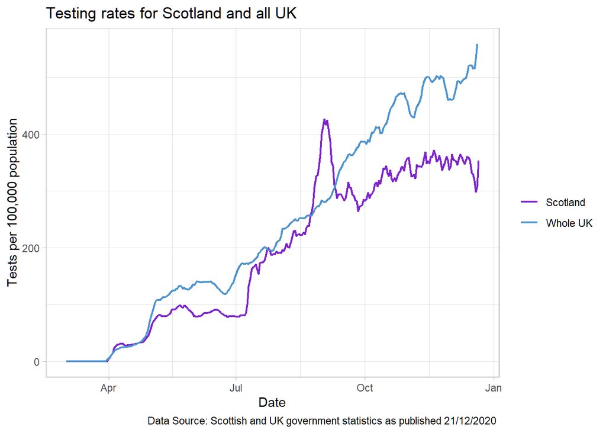

```r
###############################################################
## Scottish and UK testing data
# Prepare
v_title="Testing rates for Scotland and all UK"
v_xlabel = "Date"
v_ylabel = "Tests per 100,000 population"
v_image_file_name = paste(today, "Compare Testing Rates.jpg", sep = "", collapse=NULL)
v_image_file_name_zoom = paste(today, "Compare Testing Rates zoom.jpg", sep = "", collapse=NULL)

##-----------Sco/UK testing comparison ----------------------------------------
# All Data
df_sc_uk_test <- data.frame(j_sco_uk_testing) %>%
  select(date_notified, uk_daily_tests_per_100_000_ma, sco_daily_tests_per_100_000_ma) %>%
  gather(key = "variable", value = "value",-date_notified)
#head(df_sc_uk_test)

# from 1st August
# Sco/UK testing comparison from 1st August
df_sc_uk_test_zoom <- data.frame(j_sco_uk_testing_zoom) %>%
  select(date_notified, uk_daily_tests_per_100_000_ma, sco_daily_tests_per_100_000_ma) %>%
  gather(key = "variable", value = "value",-date_notified)
#head(df_sc_uk_test_zoom)

#PLOTS
ggplot(df_sc_uk_test, aes(x = date_notified, y = value)) +
p_geom  + theme_light() +
  scale_color_manual(labels = c("Scotland", "Whole UK"),values = c("purple3", "steelblue3") ) +  # OK #
      labs(x = v_xlabel, y = v_ylabel, title = v_title, caption = v_caption, color = "") +
ggsave(here("figures", v_image_file_name), dpi = 180, width = 8, height = 6)
```

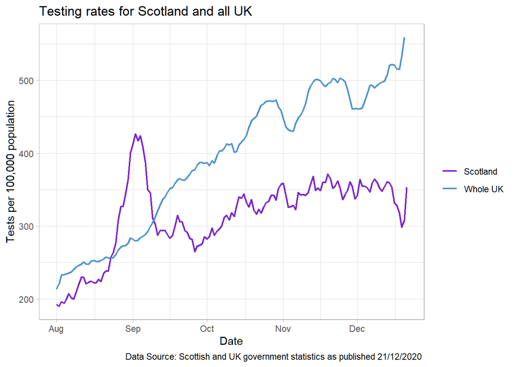

```r
ggplot(df_sc_uk_test_zoom, aes(x = date_notified, y = value)) +
  p_geom  + theme_light() +
  scale_color_manual(labels = c("Scotland", "Whole UK"),values = c("purple3", "steelblue3") ) +  # OK #
      labs(x = v_xlabel, y = v_ylabel, title = v_title, caption = v_caption, color = "") +
ggsave(here("figures", v_image_file_name_zoom), dpi = 180, width = 8, height = 6)
```

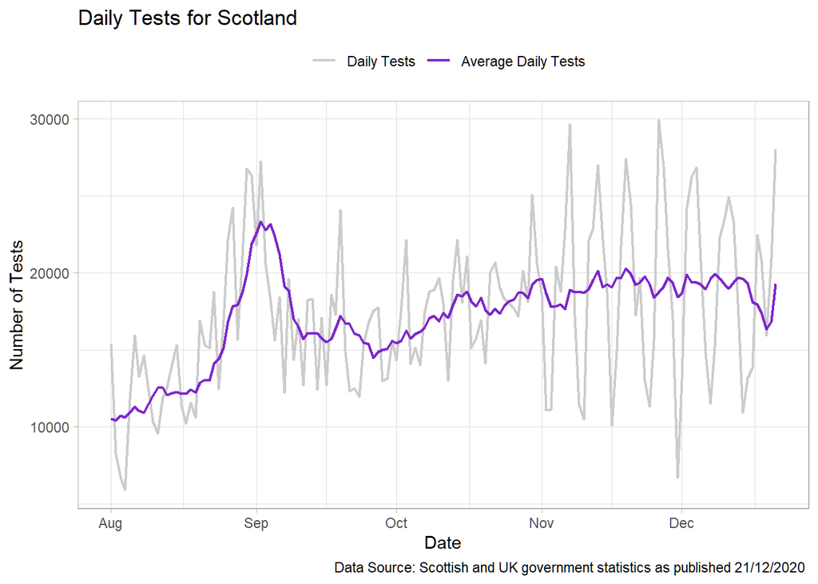

```r
#------------------------------------------------------------------------------
# Daily Tests plus MA

df_sc_test_ma_raw_zoom <- data.frame(j_sco_uk_testing_zoom) %>%
  select(date_notified, scot_daily_tests, z_scot_daily_tests_7_day_ma ) %>%
  gather(key = "variable", value = "value",-date_notified)
#head(df_sc_positive_zoom)
# Change image file name MA and RAW
v_title="Daily Tests for Scotland"
v_xlabel = "Date"
v_ylabel = "Number of Tests"
v_image_file_name = paste(today, "Daily Tests MA + Raw zoom.jpg", sep = "", collapse=NULL)
ggplot(df_sc_test_ma_raw_zoom, aes(x = date_notified, y = value)) +
  p_geom  + theme_light() + theme(legend.position = "top")+
#scale_y_discrete(limits=c("1","2","3", "4", "5" ,"6", "7", "8", "9", "10", "11")) +
  scale_color_manual(labels = c( "Daily Tests", "Average Daily Tests"),values = c(  "gray80", "purple3") ) +
  labs(x = v_xlabel, y = v_ylabel, title = v_title, caption = v_caption, color = "") +
ggsave(here("figures", v_image_file_name), dpi = 180, width = 8, height = 6)
```

```r
#------------------------------------------------------------------------------
```

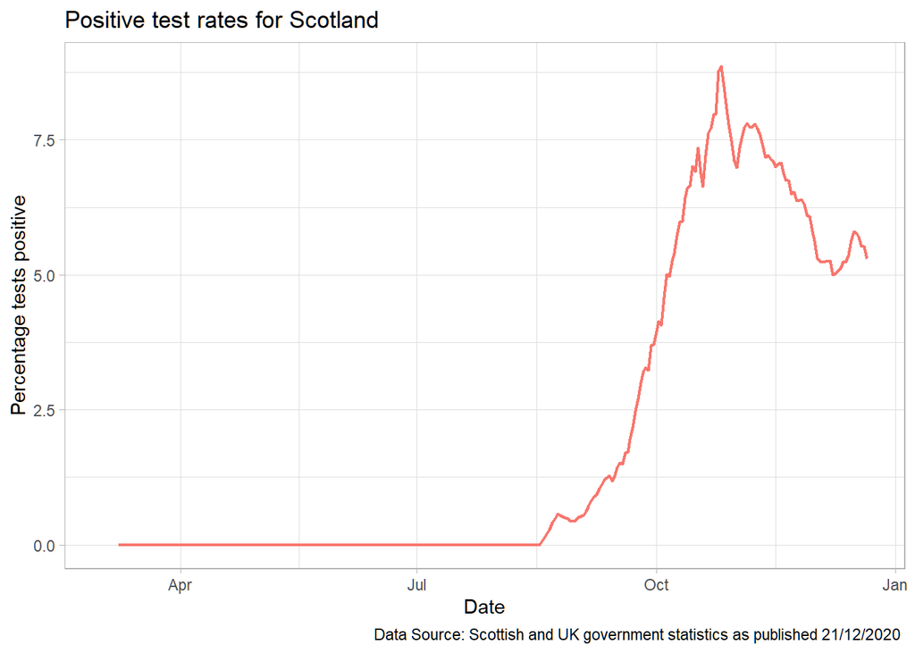

```r
#---------- Daily Positive Data ------------------------------------------------
# Prepare
v_title="Positive test rates for Scotland"
v_xlabel = "Date"
v_ylabel = "Percentage tests positive"
v_image_file_name = paste(today, "Compare Testing Rates.jpg", sep = "", collapse=NULL)
v_image_file_name_zoom = paste(today, "Compare Testing Rates zoom.jpg", sep = "", collapse=NULL)

# Daily positives all data
df_sc_positive <- data.frame(j_sco_uk_testing) %>%
  select(date_notified, percent_daily_positive_ma) %>%
  gather(key = "variable", value = "value",-date_notified)
#head(df_sc_positive)

# Daily positives MA from 1st August
df_sc_positive_zoom <- data.frame(j_sco_uk_testing_zoom) %>%
  select(date_notified, percent_daily_positive_ma) %>%
  gather(key = "variable", value = "value",-date_notified)
#head(df_sc_positive_zoom)

# Daily positives MA and raw from 1st August
df_sc_positive_raw_zoom <- data.frame(j_sco_uk_testing_zoom) %>%
  select(date_notified, percent_daily_positive_ma, percent_daily_positive_adj) %>%
  gather(key = "variable", value = "value",-date_notified)
#head(df_sc_positive_zoom)

# Change image file name
v_image_file_name = paste(today, "Percent daily positive MA.jpg", sep = "", collapse=NULL)
ggplot(df_sc_positive, aes(x = date_notified, y = value)) +
  p_geom  + theme_light() + theme(legend.position = "none")+
  labs(x = v_xlabel, y = v_ylabel, title = v_title, caption = v_caption, color = "") +
ggsave(here("figures", v_image_file_name), dpi = 180, width = 8, height = 6)
```

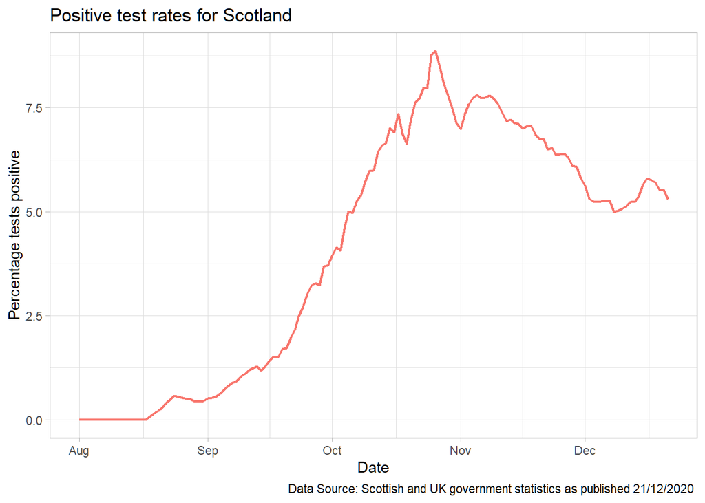

```r
# Change image file name
v_image_file_name = paste(today, "Percent daily positive MA zoom.jpg", sep = "", collapse=NULL)
ggplot(df_sc_positive_zoom, aes(x = date_notified, y = value)) +
  p_geom  + theme_light() + theme(legend.position = "none")+
  labs(x = v_xlabel, y = v_ylabel, title = v_title, caption = v_caption, color = "") +
ggsave(here("figures", v_image_file_name), dpi = 180, width = 8, height = 6)
```

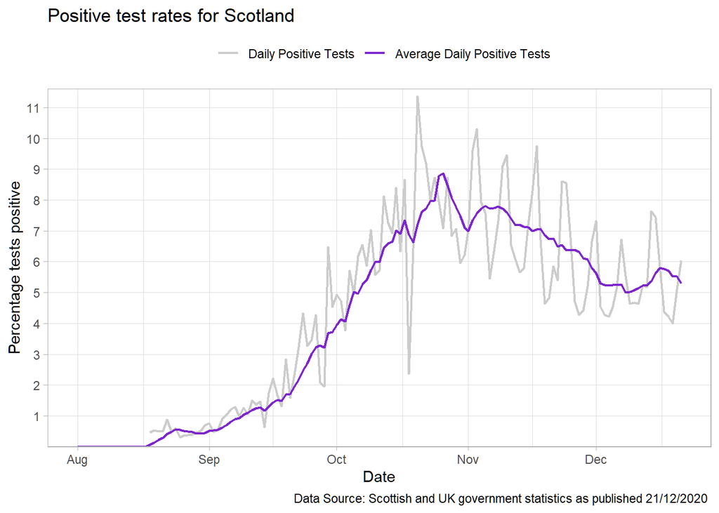

```r
# Change image file name MA and RAW
p_geom2 <-geom_line(aes(color = variable),size=0.75, axis.ticks.y = 1 )
v_image_file_name = paste(today, "Percent daily positive MA + Raw zoom.jpg", sep = "", collapse=NULL)
ggplot(df_sc_positive_raw_zoom, aes(x = date_notified, y = value)) +
  p_geom  + theme_light() + theme(legend.position = "top")+
scale_y_discrete(limits=c("1","2","3", "4", "5" ,"6", "7", "8", "9", "10", "11")) +
  scale_color_manual(labels = c("Daily Positive Tests", "Average Daily Positive Tests"),values = c("gray80", "purple3") ) +
  labs(x = v_xlabel, y = v_ylabel, title = v_title, caption = v_caption, color = "") +
ggsave(here("figures", v_image_file_name), dpi = 180, width = 8, height = 6)
```

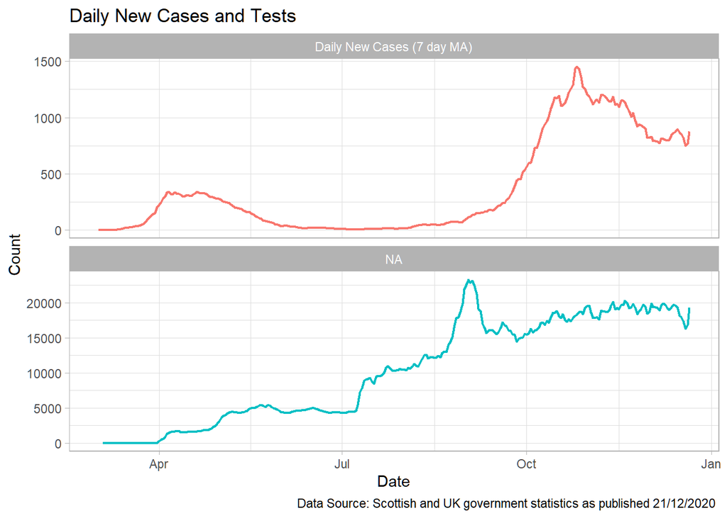

```r
#-----------------Compare Tests and new cases-----------------------------------
# Second compares testing and case numbers.
df_sc_t5 <- data.frame(j_sco_uk_testing) %>%
  select(date_notified, daily_new_cases_ma, z_scot_daily_tests_7_day_ma) %>%
  gather(key = "variable", value = "value",-date_notified)
#head(df_sc_t5)

# Same data but from 1st August
df_sc_t5_zoom <- data.frame(j_sco_uk_testing_zoom) %>%
  select(date_notified, daily_new_cases_ma, z_scot_daily_tests_7_day_ma) %>%
  gather(key = "variable", value = "value",-date_notified)
#head(df_sc_t5_zoom)

# Same data but from 1st August
df_sc_t5_pos_zoom <- data.frame(j_sco_uk_testing_zoom) %>%
  select(date_notified, daily_new_cases_ma, z_scot_daily_tests_7_day_ma) %>%
  gather(key = "variable", value = "value",-date_notified)
#head(df_sc_t5_pos_zoom)
# Then the Sco testing and case numbers
# Change image file name
##v_image_file_name = paste(today, "Testing v Case Numbers.jpg", sep = "", collapse=NULL)
##ggplot(df_sc_t5, aes(x = date_notified, y = value)) +
##  p_geom + theme_light() +theme(legend.position = "none")+
##    facet_wrap(~ variable, ncol=1, labeller = labels_SCO_UK_Test, scales = "free_y")
#ggsave(here("figures", v_image_file_name), dpi = 180, width = 8, height = 6)

# Then the Sco testing and case numbers
# Change image file name
v_title="Daily New Cases and Tests"
v_xlabel = "Date"
v_ylabel = "Count"
# Testing v positive tests
v_image_file_name = paste(today, "Testing v New Cases.jpg", sep = "", collapse=NULL)
ggplot(df_sc_t5, aes(x = date_notified, y = value)) +
    p_geom + theme_light() +theme(legend.position = "none")+
      labs(x = v_xlabel, y = v_ylabel, title = v_title, caption = v_caption, color = "") +
  facet_wrap(~ variable , labeller = labels_28_day_deaths , ncol=1, scales = "free_y")
```

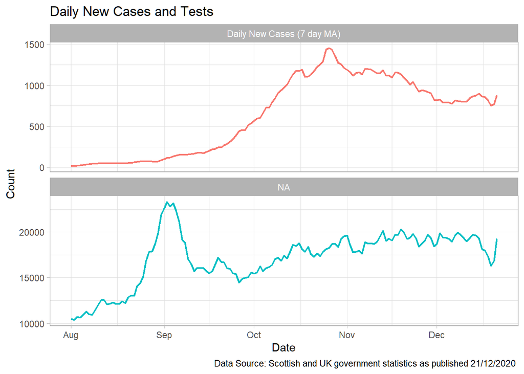

```r
ggsave(here("figures", v_image_file_name), dpi = 180, width = 8, height = 6)
v_image_file_name = paste(today, "Testing v New Cases zooms.jpg", sep = "", collapse=NULL)
ggplot(df_sc_t5_pos_zoom, aes(x = date_notified, y = value)) +
    p_geom + theme_light() +theme(legend.position = "none")+
      labs(x = v_xlabel, y = v_ylabel, title = v_title, caption = v_caption, color = "") +
  facet_wrap(~ variable , labeller = labels_28_day_deaths, ncol=1, scales = "free_y")
```

```r
ggsave(here("figures", v_image_file_name), dpi = 180, width = 8, height = 6)
```

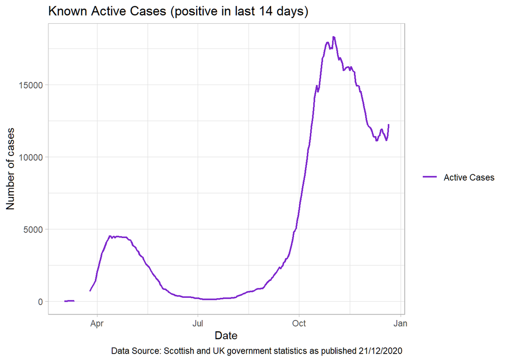

```r
##---------Active Cases - Positive within 14 days ------------------------------
#  Active Cases
# Daily Active cases (14)
df_sc_new_cases <- data.frame(j_sco_uk_testing) %>%
  select(date_notified, new_cases_last_14_days) %>%
  gather(key = "variable", value = "value",-date_notified)
#head(df_sc_new_cases)

# Daily Active cases (14)
df_sc_new_cases_zoom <- data.frame(j_sco_uk_testing_zoom) %>%
  select(date_notified, new_cases_last_14_days) %>%
  gather(key = "variable", value = "value",-date_notified)
#head(df_sc_new_cases_zoom)

#------------------------------------------------------------------------------------
#  Active Cases
v_title="Known Active Cases (positive in last 14 days)"
v_xlabel = "Date"
v_ylabel = "Number of cases"
v_image_file_name = paste(today, "Active Cases Scotland.jpg", sep = "", collapse=NULL)
ggplot(df_sc_new_cases, aes(x = date_notified, y = value)) +
p_geom  + theme_light() +
  #  geom_line(aes(color = variable),size=1 )
  scale_color_manual(labels = c("Active Cases"),values = c("purple3") ) +
      labs(x = v_xlabel, y = v_ylabel, title = v_title, caption = v_caption, color = "") +
ggsave(here("figures", v_image_file_name), dpi = 180, width = 8, height = 6)
```

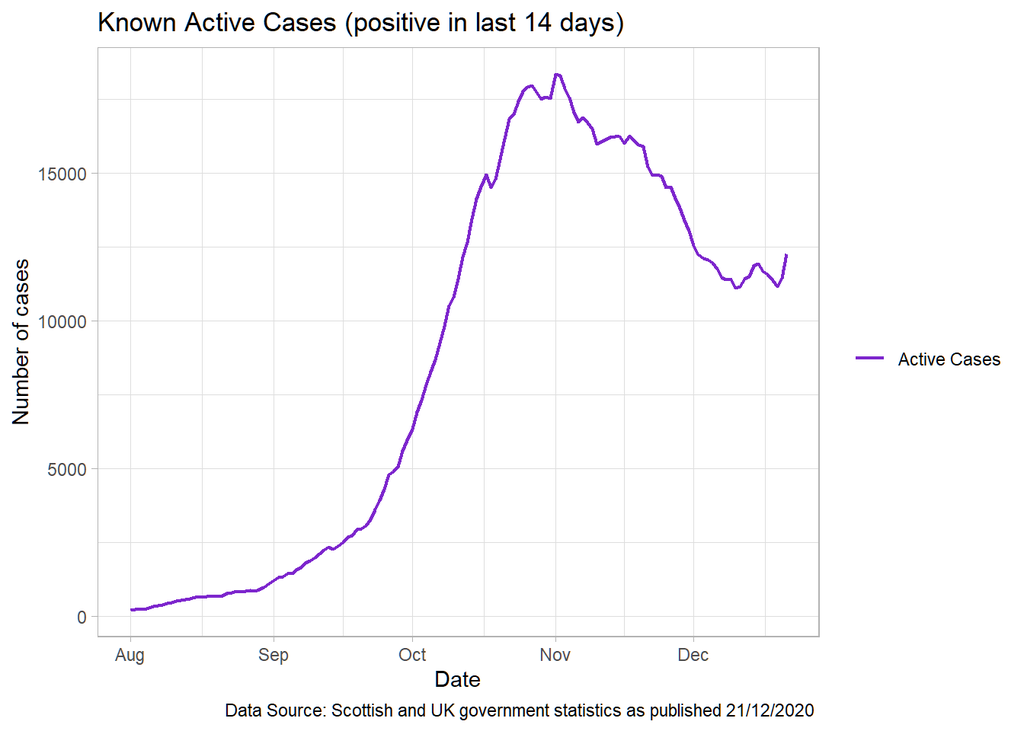

```r
#------------------------------------------------------------------------------------
# Change image file name
v_image_file_name = paste(today, "Active Cases Scotland zoom.jpg", sep = "", collapse=NULL)
ggplot(df_sc_new_cases_zoom, aes(x = date_notified, y = value)) +
p_geom  + theme_light() +
  #  geom_line(aes(color = variable),size=1 )
  scale_color_manual(labels = c("Active Cases"),values = c("purple3") ) +
      labs(x = v_xlabel, y = v_ylabel, title = v_title, caption = v_caption, color = "") +
ggsave(here("figures", v_image_file_name), dpi = 180, width = 8, height = 6)
```

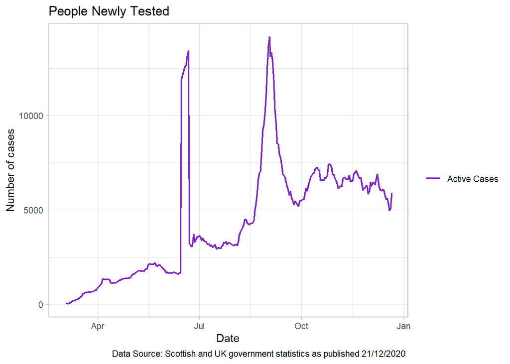

```r
##---------Number of people newly tested ------------------------------
# Newly Tested MA
df_sc_new_tests <- data.frame(j_sco_uk_testing) %>%
  select(date_notified, people_newly_tested_ma) %>%
  gather(key = "variable", value = "value",-date_notified)
#head(df_sc_new_cases)

# Newly Tested MA
df_sc_new_tests_zoom <- data.frame(j_sco_uk_testing_zoom) %>%
  select(date_notified, people_newly_tested_ma) %>%
  gather(key = "variable", value = "value",-date_notified)
#head(df_sc_new_cases_zoom)

#------------------------------------------------------------------------------------
# Newly Tested MA
v_title="People Newly Tested"
v_xlabel = "Date"
v_ylabel = "Number of cases"
v_image_file_name = paste(today, "People Newly Tested.jpg", sep = "", collapse=NULL)
ggplot(df_sc_new_tests, aes(x = date_notified, y = value)) +
p_geom  + theme_light() +
  #  geom_line(aes(color = variable),size=1 )
  scale_color_manual(labels = c("Active Cases"),values = c("purple3") ) +
      labs(x = v_xlabel, y = v_ylabel, title = v_title, caption = v_caption, color = "") +
ggsave(here("figures", v_image_file_name), dpi = 180, width = 8, height = 6)
```

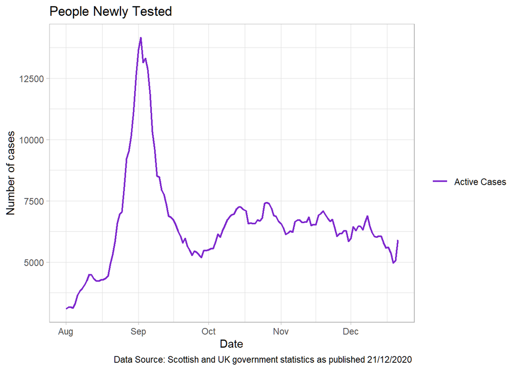

```r
#------------------------------------------------------------------------------------
# Change image file name
v_image_file_name = paste(today, "People Newly Tested zoom.jpg", sep = "", collapse=NULL)
ggplot(df_sc_new_tests_zoom, aes(x = date_notified, y = value)) +
p_geom  + theme_light() +
  #  geom_line(aes(color = variable),size=1 )
  scale_color_manual(labels = c("Active Cases"),values = c("purple3") ) +
      labs(x = v_xlabel, y = v_ylabel, title = v_title, caption = v_caption, color = "") +
ggsave(here("figures", v_image_file_name), dpi = 180, width = 8, height = 6)
```

```r
#------- Deaths within 28 days of positive test (UK)----------------------------
## UK 28 days death data
#
# Now deaths within 28 days of a positive test
df_uk_d28_pos <- data.frame(j_uk_d_28_day_testing) %>%
  select(date_notified, england_7_day_ma_per_100_000:wales_7_day_ma_per_100_000) %>%
  gather(key = "variable", value = "value",-date_notified)
# head(df_uk_d28_pos)

# Same data but from 1st August
df_uk_d28_pos_zoom <- data.frame(j_uk_d_28_day_testing_zoom) %>%
  select(date_notified, england_7_day_ma_per_100_000:wales_7_day_ma_per_100_000) %>%
  gather(key = "variable", value = "value",-date_notified)
head(df_uk_d28_pos_zoom)
```

```
##   date_notified                     variable    value
## 1    2020-08-01 england_7_day_ma_per_100_000 1.225860
## 2    2020-08-02 england_7_day_ma_per_100_000 1.119264
## 3    2020-08-03 england_7_day_ma_per_100_000 1.190328
## 4    2020-08-04 england_7_day_ma_per_100_000 1.190328
## 5    2020-08-05 england_7_day_ma_per_100_000 1.101498
## 6    2020-08-06 england_7_day_ma_per_100_000 1.119264
```

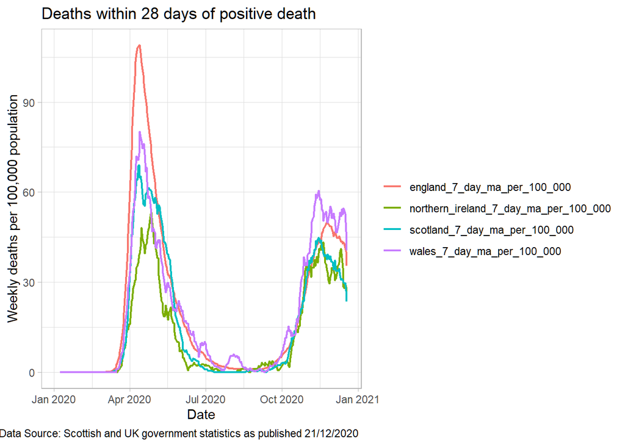

```r
v_title="Deaths within 28 days of positive death"
v_ylabel = "Weekly deaths per 100,000 population"
# Change image file name
v_image_file_name = paste(today, "Deaths within 28 days.jpg", sep = "", collapse=NULL)
ggplot(df_uk_d28_pos, aes(x = date_notified, y = value)) +
  p_geom  + theme_light() +
  labs(x = v_xlabel, y = v_ylabel, title = v_title, caption = v_caption, color = "") +
ggsave(here("figures", v_image_file_name), dpi = 180, width = 8, height = 6)
```

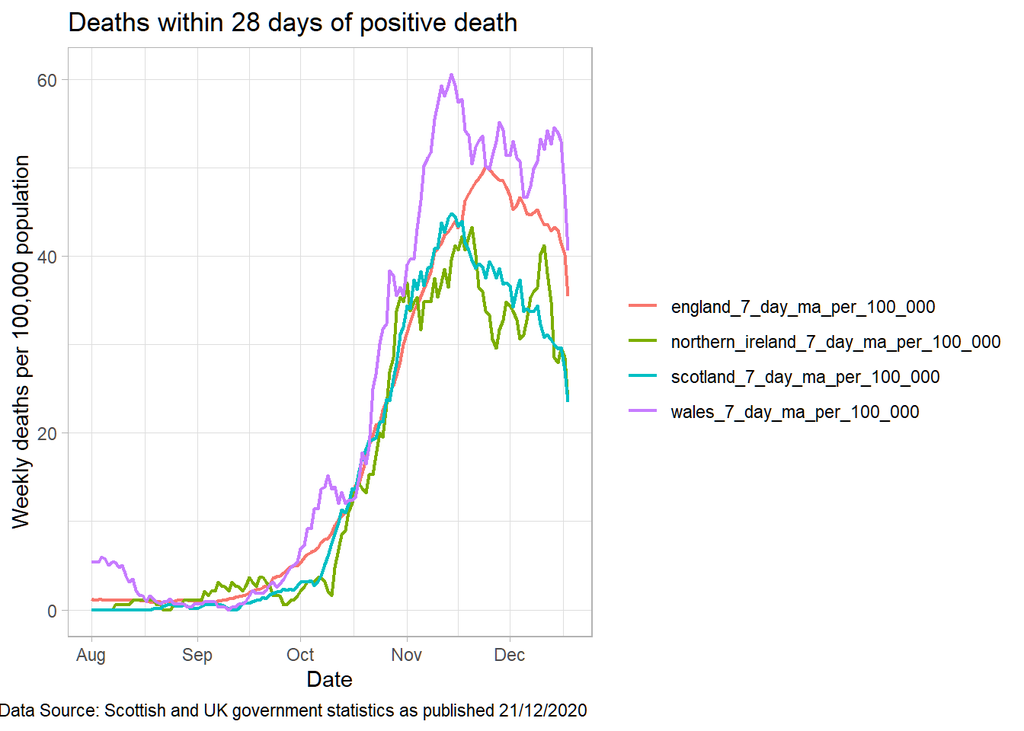

```r
# Change image file name
v_image_file_name = paste(today, "Deaths within 28 days zoom.jpg", sep = "", collapse=NULL)
ggplot(df_uk_d28_pos_zoom, aes(x = date_notified, y = value)) +
  p_geom  + theme_light() +
  labs(x = v_xlabel, y = v_ylabel, title = v_title, caption = v_caption, color = "") +
ggsave(here("figures", v_image_file_name), dpi = 180, width = 8, height = 6)
```

```r
#------------------------------------------------------------------------------------
```

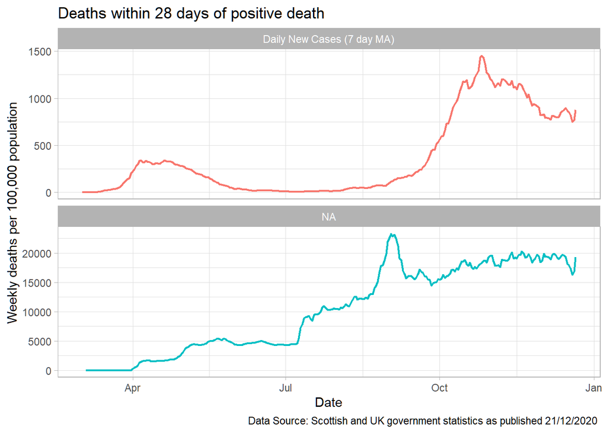

```r
#------------------------------------------------------------------------------------
##########################################################################
## TO DO

#------------------------------------------------------------------------------------
# Testing v Positive Tests v Active Cases
v_image_file_name = paste(today, "Testing v New Cases.jpg", sep = "", collapse=NULL)
ggplot(df_sc_t5, aes(x = date_notified, y = value)) +
    p_geom + theme_light() +theme(legend.position = "none")+
      labs(x = v_xlabel, y = v_ylabel, title = v_title, caption = v_caption, color = "") +
  facet_wrap(~ variable , labeller = labels_28_day_deaths , ncol=1, scales = "free_y")
```

```r
#ggsave(here("figures", v_image_file_name), dpi = 180, width = 8, height = 6)

#v_image_file_name = paste(today, "Testing v New Cases zooms.jpg", sep = "", collapse=NULL)
#ggplot(df_sc_t5_pos_zoom, aes(x = date_notified, y = value)) +
#    p_geom + theme_light() +theme(legend.position = "none")+
#      labs(x = v_xlabel, y = v_ylabel, title = v_title, caption = v_caption, color = "") +
#  facet_wrap(~ variable , labeller = labels_28_day_deaths, ncol=1, scales = "free_y")
#ggsave(here("figures", v_image_file_name), dpi = 180, width = 8, height = 6)
```